# HW3

Simay Gökalp

06 06 2021

## Hw 3

### Introduction

In this Homework, I will be examining electricity consumption released by EPIAŞ. Electricity consumption, as we have seen during the lectures based on the weather, special days or specific events, such as university entrance exams, religious holidays, etc. After this examination, I will try to find a pattern that the consumption follows and a general trend. We will use this pattern to decompose it from the data, and then I will use AR, MA and their combination to determine the best fitting prediction method. Such predictions based on consumption is important for companies to plan their production schedules or inventories. This will be a primitive version of works that most of firms deal with in real time.

### Question 1

To determine possible types of seasonality exhibited by hourly electricity consumption, I will read the data, group it to see various trends and observe the graphs and autocorrelations for different lags. My assumptions are there can be a hourly trend. Which means on 24 hours lagged hours data we can observe similar pattern. I also think when I group the data as days. There can be a daily trend, I am going to group the data as dates and check for the trends. To examine weekly trend, I will check 7 days autocorrelation. I also group the data according to the months and check the monthly trend over the time. Then, I will decompose the series according to my findings and comment on the remaining randomized data and my success of the trend cath.

Libraries for the homework.

```r
library(readr)
library(data.table)
library(ggplot2)
library(urca)
library(zoo)
```

Reading the data and transforming date into the data format that R can understand and changing names into appropriate formats:

```
##  Date[1:47208], format: "2016-01-01" "2016-01-01" "2016-01-01" "2016-01-01" "2016-01-01" ...
```

Let’s check for the overtime daily trend of data.

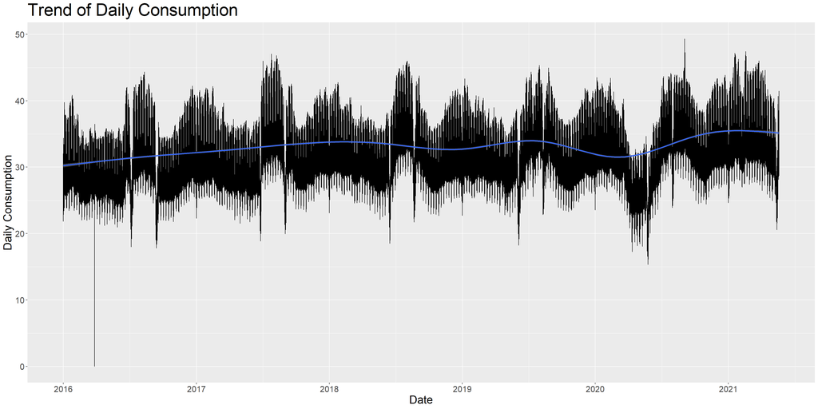

```r
ggplot(data, aes(x=date, y=cons)) + geom_line() + stat_smooth() +

  xlab("") + scale_x_date(date_breaks = "1 year", date_labels = "%Y") +
  theme(axis.text.x = element_text(size = 15)) + theme(axis.text.y = element_text(size = 15)) +
  xlab("Date") + ylab("Daily Consumption") + theme(axis.title.x = element_text(size = 20)) + theme(axis.title.y=element_text(size = 20)) + ggtitle("Trend of Daily Consumption") + theme(title = element_text(size = 25))
```

On this graph as there are too many data points to observe we cannot see the pattern. Also the data points are lines because of the hour fractions and their representations. Let’s check for a smaller period and examine the data for hourly trend. Let’s check 24 * 30, 1 month hourly data, data points to see whether there is a pattern that we can detect. THis will give me a general overview. To see this we also add the trend factor, 1 to N index to the data.

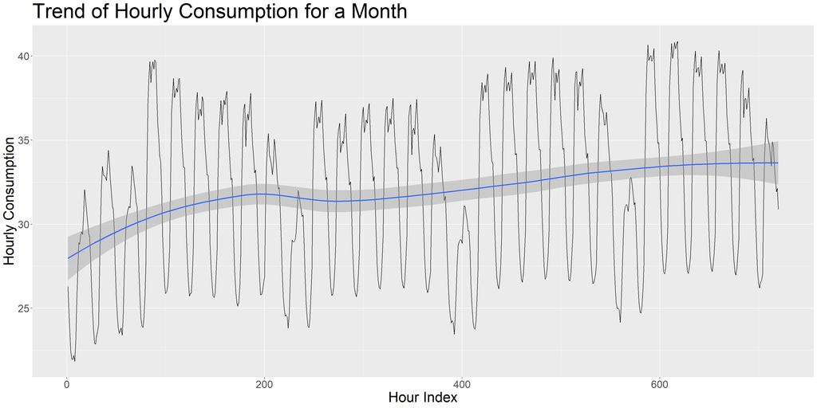

```r
data <- as.data.table(data)
data <- data[,trend:=1:.N]

data_first <- data[1:720,]

ggplot(data_first, aes(x=trend, y=cons)) + geom_line() + stat_smooth() +   theme(axis.text.x = element_text(size = 18)) + theme(axis.text.y = element_text(size = 18)) +
  xlab("Hour Index") + ylab("Hourly Consumption") + theme(axis.title.x = element_text(size = 25)) + theme(axis.title.y=element_text(size = 25)) + ggtitle("Trend of Hourly Consumption for a Month") + theme(title = element_text(size = 30))
```

It is obvious that there is an observable trend in the data. We can understand it from the number of peaks. It indicates daily trend. There are some low peaks which is an indicator of a possible weekly trend.

To see the hourly trend in a close look, more clearly let’s observe a smaller interval, three days which means 3*24 data point.

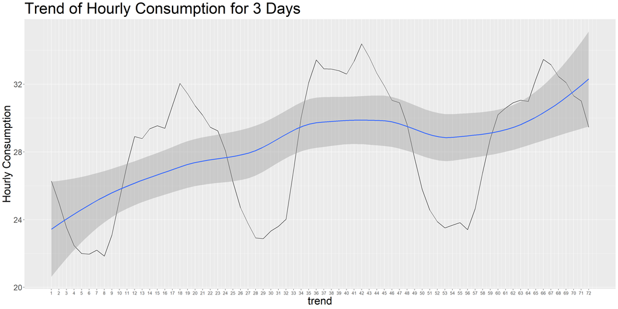

```r
data_first_2 <- data[1:72,]

ggplot(data_first_2, aes(x=trend, y=cons)) + geom_line() + stat_smooth() + scale_x_continuous("trend", labels = as.character(data_first_2$trend), breaks = data_first_2$trend) +   theme(axis.text.x = element_text(size = 10)) + theme(axis.text.y = element_text(size = 18)) +
  xlab("Hour Index") + ylab("Hourly Consumption") + theme(axis.title.x = element_text(size = 25)) + theme(axis.title.y=element_text(size = 25)) + ggtitle("Trend of Hourly Consumption for 3 Days") + theme(title = element_text(size = 30))
```

Our assumption seems correct, we can see that 24 hours the pattern. The autocorrelation and partial autocorrelation plots will help us to understand the trend better.

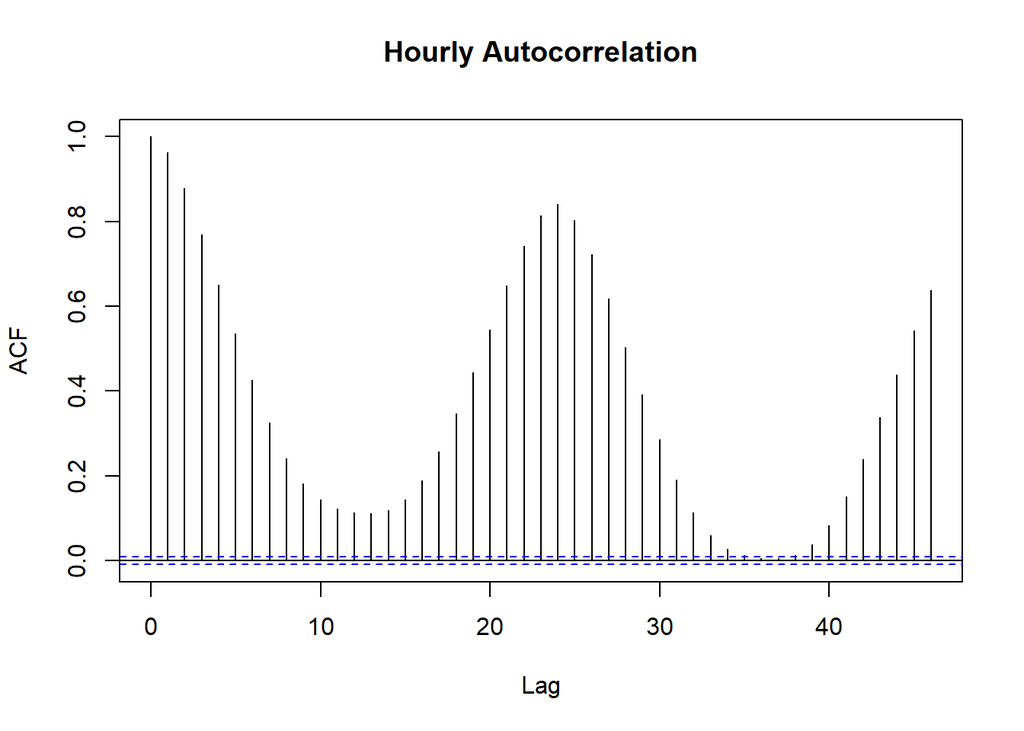

```r
acf(data$cons, main= "Hourly Autocorrelation")
```

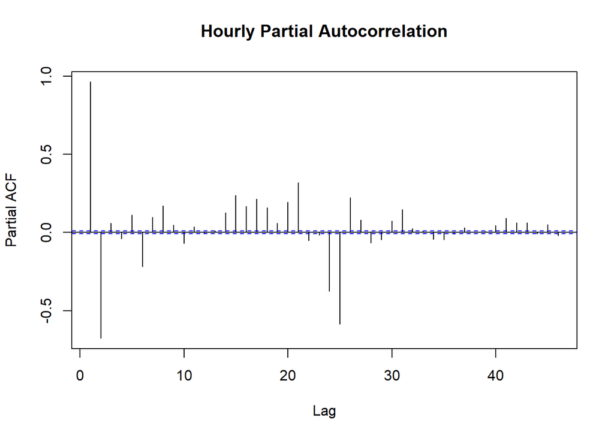

```r
pacf(data$cons, main = "Hourly Partial Autocorrelation")
```

The autocorrelaton plot proves that there is an hourly trend in the data. Because it makes a wave similar to a cosine plot. Also we can see many partial autocorrelatios out of the limits. There is hourly trend.

I will decompose the series hourly with a frequency of 24 hours and examine the remaining error data.

```r
datats<-ts(data$cons,freq=24)
```

To determine the decomposition method, I will try both additive and multiplicative methods and see the remaining part of the data to determine the stationarity of the random part.

Starting with the multiplicative decomposition:

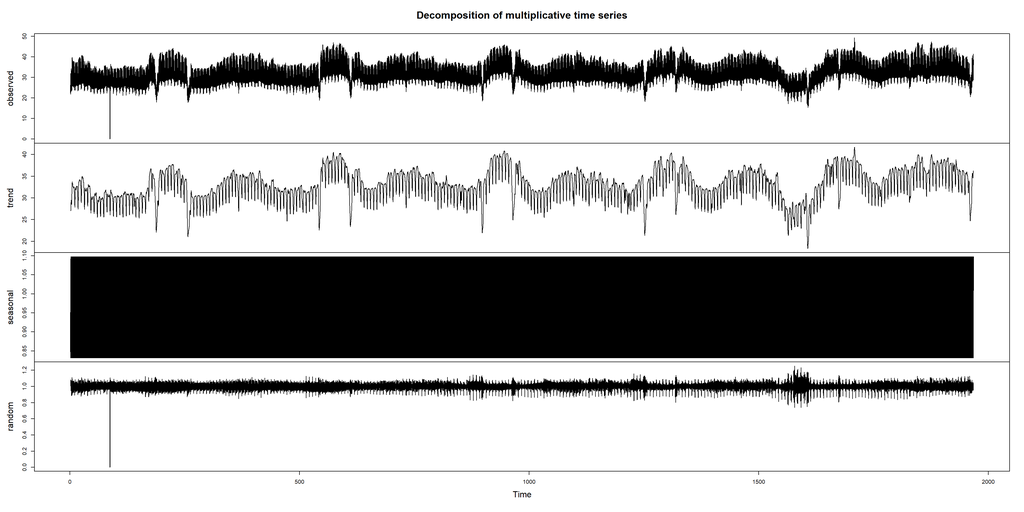

```r
data_mult<-decompose(datats,type="multiplicative")
random=data_mult$random
plot(data_mult)
```

Trend data seems to catch, the overall trend. However, there is another seasonality in the trend itself that can be explained by weekly, monthly or yearly trend. We cannot see the seasonality component from here as there are too many points. Let’s give the seasonality a close look.

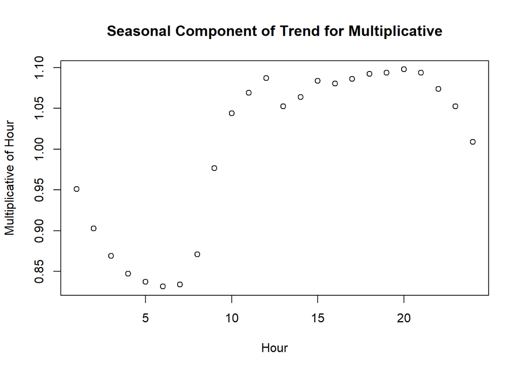

```r
plot(data_mult$seasonal[1:24], xlab = "Hour", ylab = "Multiplicative of Hour", main = "Seasonal Component of Trend for Multiplicative")
```

The seasonality tells us that between 15:00 - 20:00 , the consumption is at its maximum, which makes sense the weather is starts to darken and it is the busy hours of the day. And after 20:00, it starts to decrease. Between 3:00 and 7:00 in the morning it is on its lowest level, which makes perfect sense as lots of people is asleep during that hours.

To determine whether the remaining data is randomized, let’s see the KPSS test:

```r
unt_test=ur.kpss(data_mult$random)
summary(unt_test)
```

```
##
## #######################
## # KPSS Unit Root Test #
## #######################
##
## Test is of type: mu with 18 lags.
##
## Value of test-statistic is: 0.5202
##
## Critical value for a significance level of:
##                 10pct  5pct 2.5pct  1pct
## critical values 0.347 0.463  0.574 0.739
```

The level is between 5 percent and 2.5 percent. The stationary depends on our confidence interval. For 1 percent, we fail reject the data is stationary, however for 10 we reject. Actually it is normal the data does not take into consideration for example the weekly trend.

Let’s check additive model and compare those.

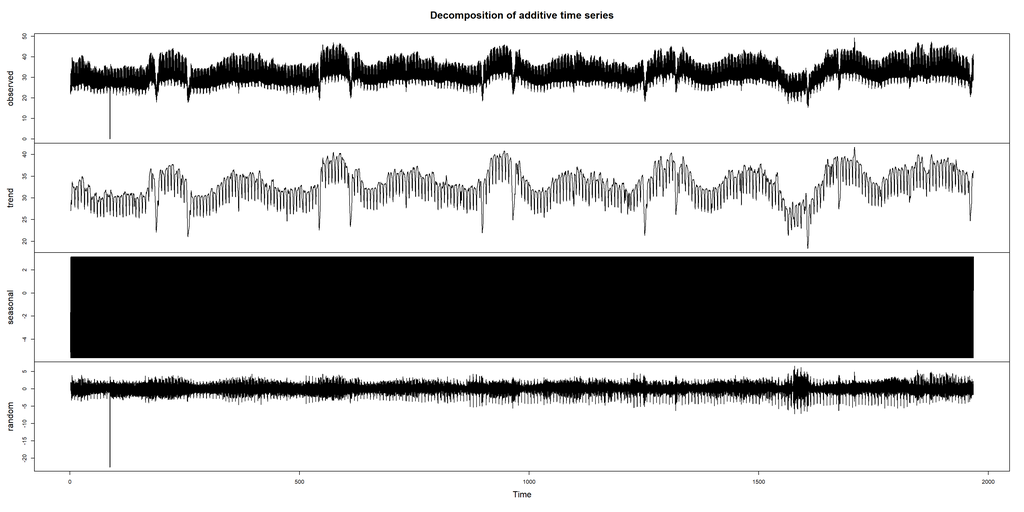

```r
data_add<-decompose(datats,type="additive")
random=data_add$random
plot(data_add)
```

Trend and random factor is pretty similar of the two model but with different parameters.

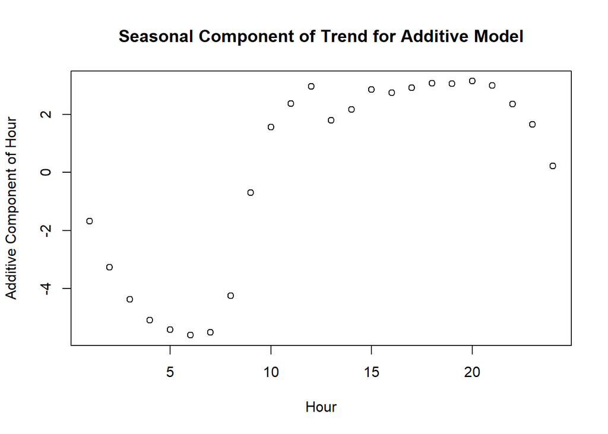

```r
plot(data_add$seasonal[1:24], xlab = "Hour", ylab = "Additive Component of Hour", main = "Seasonal Component of Trend for Additive Model")
```

We see same pattern, with different parameters.

```r
unt_test=ur.kpss(data_add$random)
summary(unt_test)
```

```
##
## #######################
## # KPSS Unit Root Test #
## #######################
##
## Test is of type: mu with 18 lags.
##
## Value of test-statistic is: 3e-04
##
## Critical value for a significance level of:
##                 10pct  5pct 2.5pct  1pct
## critical values 0.347 0.463  0.574 0.739
```

Although, the patterns were very similar, we see that the stationary test on additive model test statistics were lower.

Let’s continue to examine the data daily and weekly.

To see daily trend better, let’s group the data daily. We can take the mean or the sum of the hourly consumption to calculate daily data. I will have both but as we use mean during the lectures, I will use mean data in my evaluations.

```r
daily_consumption_sum=data[,list(sum_consumption = sum(cons,na.rm=T)), by=list(date)]

daily_consumption=data[,list(mean_consumption = mean(cons,na.rm=T)), by=list(date)]
```

Let’s see the trend on the data.

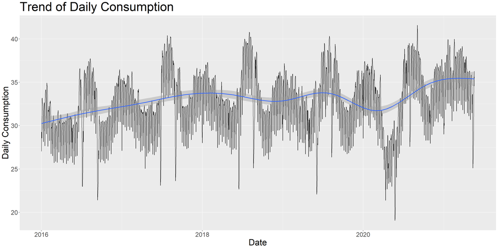

```r
ggplot(daily_consumption, aes(x=date, y=mean_consumption)) + geom_line() + stat_smooth() +   theme(axis.text.x = element_text(size = 18)) + theme(axis.text.y = element_text(size = 18)) +
  xlab("Date") + ylab("Daily Consumption") + theme(axis.title.x = element_text(size = 25)) + theme(axis.title.y=element_text(size = 25)) + ggtitle("Trend of Daily Consumption") + theme(title = element_text(size = 30))
```

We can see there is a general trend, however it is hard to observe pattern as there are too many data points. Let’s see it for the first 90 days, 3 months period.

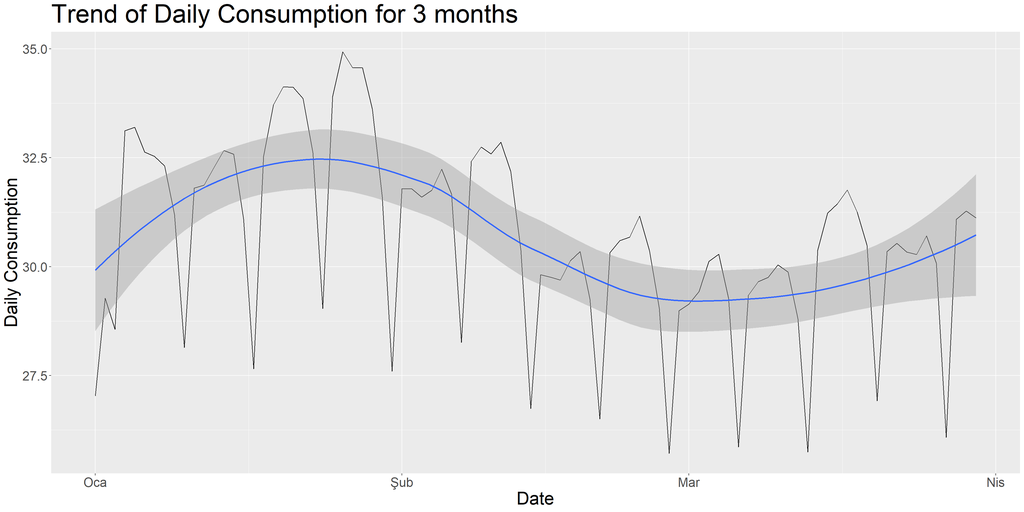

```r
daily_consumption_first <- daily_consumption[1:90,]

ggplot(daily_consumption_first, aes(x=date, y=mean_consumption)) + geom_line() + stat_smooth() +   theme(axis.text.x = element_text(size = 18)) + theme(axis.text.y = element_text(size = 18)) +
  xlab("Date") + ylab("Daily Consumption") + theme(axis.title.x = element_text(size = 25)) + theme(axis.title.y=element_text(size = 25)) + ggtitle("Trend of Daily Consumption for 3 months") + theme(title = element_text(size = 30))
```

Yes, we can see the weekly pattern clearly from the peaks. It seems like we have a daily patterns also. To check we should look autocorrelation and partial autocorrelation.

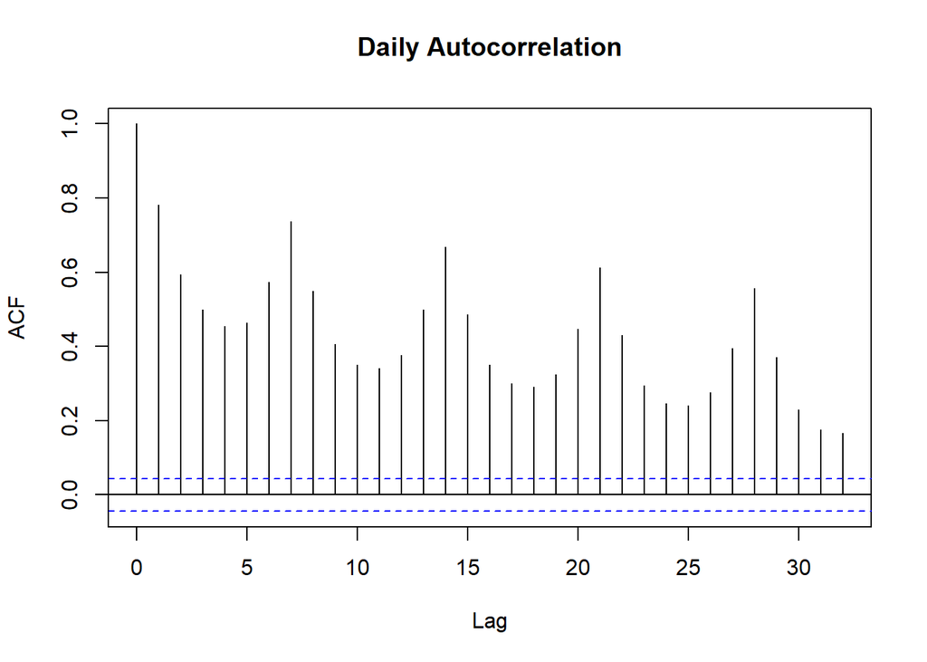

```r
acf(daily_consumption$mean_consumption, main= "Daily Autocorrelation")
```

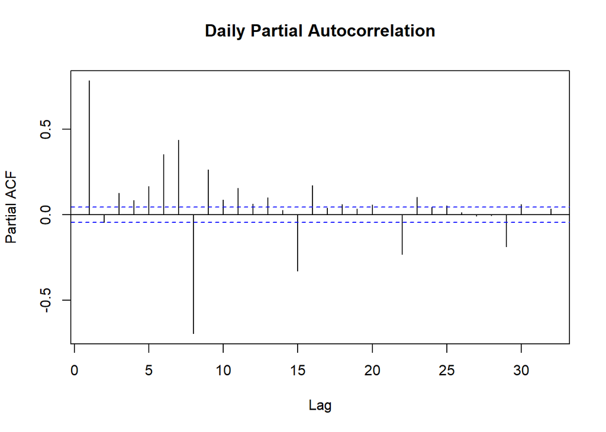

```r
pacf(daily_consumption$mean_consumption, main= "Daily Partial Autocorrelation")
```

We can see that from the autocorrelation plot, it is really high at 7, 14, etc. We can see that there is a weekly autocorrelation. Partial autocorrelation plot at lag 7 is also so out of the limits, that’s why we can say that it is also supported. On the autocorrelation plot there is decreasing trend at first, which can be indicator of a daily trend.

Let’s examine both addditive and multiplicative decomposition of the data.

```r
data_daily_ts<-ts(daily_consumption$mean_consumption,freq=7)
```

To determine the decomposition method, Again I will try both additive and multiplicative methods and see the remaining part of the data to determine the stationary of the random part.

Starting with the multiplicative decomposition:

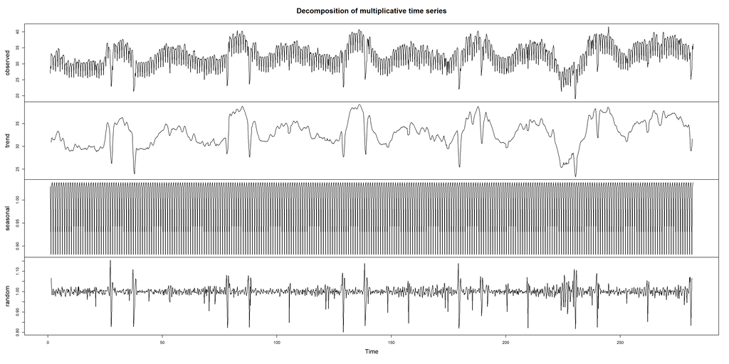

```r
data_daily_mult<-decompose(data_daily_ts,type="multiplicative")
random=data_daily_mult$random
plot(data_daily_mult)
```

General trend is reflecting the pattern very well, but the weekly trend has also have a pattern, potential due to the seasons, more usage in winters etc. The random data looks near to random, but it has peaks due to the special days.

As we cannot see the weekly parameters very well, let’s take a close look.

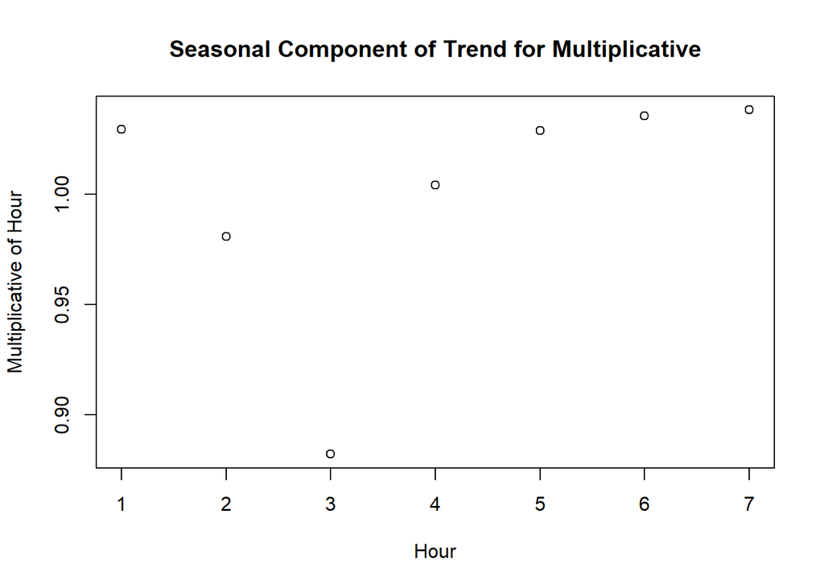

```r
plot(data_daily_mult$seasonal[1:7], xlab = "Hour", ylab = "Multiplicative of Hour", main = "Seasonal Component of Trend for Multiplicative")
```

The week on 01.01.2016 starts at Fridays so the third day which is lowest is Sundays which makes sense as many offices or factories are closed on Sunday. Saturdays have half, which is a great fit as many places works half day on Saturdays.

```r
unt_test=ur.kpss(data_daily_mult$random)
summary(unt_test)
```

```
##
## #######################
## # KPSS Unit Root Test #
## #######################
##
## Test is of type: mu with 8 lags.
##
## Value of test-statistic is: 0.0105
##
## Critical value for a significance level of:
##                 10pct  5pct 2.5pct  1pct
## critical values 0.347 0.463  0.574 0.739
```

The data is stationary, because 0.01 is lower even 0.347. Differencing results in 0.0105<0.347 implies corresponding the p-value is larger than 10%, we fail to reject the null hypothesis claiming the data are stationary.

Let’s check also additive method.

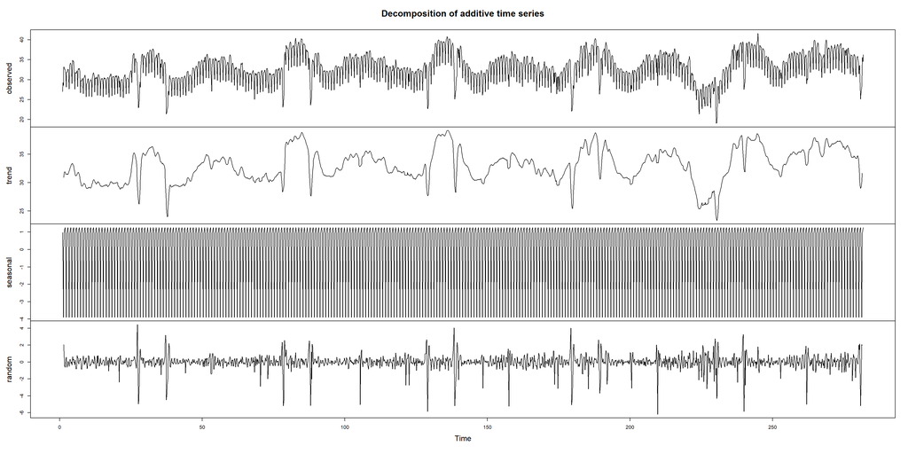

```r
data_daily_add<-decompose(data_daily_ts,type="additive")
random=data_daily_add$random
plot(data_daily_add)
```

Our explanations for multiplicative model holds also here. Let’s check seasonality in a close look, as it cannot understood from here.

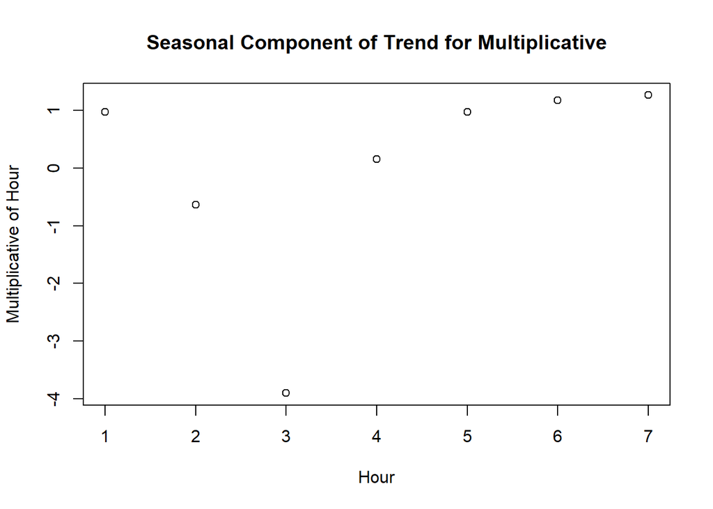

```r
plot(data_daily_add$seasonal[1:7], xlab = "Hour", ylab = "Multiplicative of Hour", main = "Seasonal Component of Trend for Multiplicative")
```

Same ratios as multiplicative with different parameters. Same comments are applicable here. Let’s see the random data’s statioanrity.

```r
unt_test=ur.kpss(data_daily_add$random)
summary(unt_test)
```

```
##
## #######################
## # KPSS Unit Root Test #
## #######################
##
## Test is of type: mu with 8 lags.
##
## Value of test-statistic is: 0.0067
##
## Critical value for a significance level of:
##                 10pct  5pct 2.5pct  1pct
## critical values 0.347 0.463  0.574 0.739
```

The data is stationary. Additive model’s test statistics were lower than multiplicative model’s.

Let’s group data monthly, and check for the montly seasonality.

Data manipulation for monthly comments:

```r
data[,month_date:=format(as.Date(data$date,  format = "%d-%m-%Y"), "%Y-%m")]

mon_consumption=data[,list(mean_consumption = mean(cons,na.rm=T)), by="month_date"]

mon_consumption$month_date = as.yearmon(mon_consumption$month_date)
```

Let’s see the trend on the monthly data.

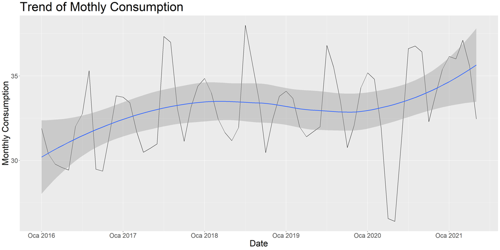

```r
ggplot(mon_consumption, aes(x=month_date, y=mean_consumption)) + geom_line() + stat_smooth() +   theme(axis.text.x = element_text(size = 18)) + theme(axis.text.y = element_text(size = 18)) +
  xlab("Date") + ylab("Monthly Consumption") + theme(axis.title.x = element_text(size = 25)) + theme(axis.title.y=element_text(size = 25)) + ggtitle("Trend of Mothly Consumption") + theme(title = element_text(size = 30))
```

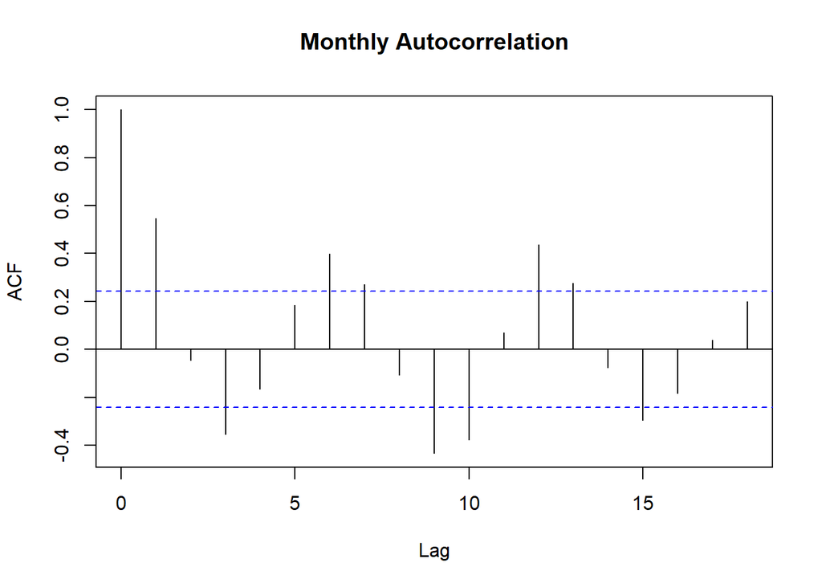

```r
acf(mon_consumption$mean_consumption, main= "Monthly Autocorrelation")
```

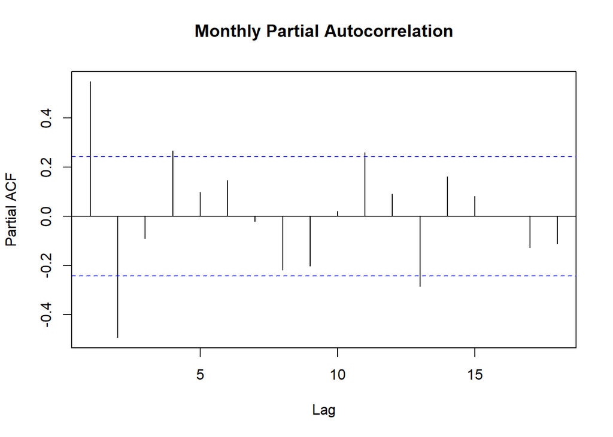

```r
pacf(mon_consumption$mean_consumption, main= "Monthly Partial Autocorrelation")
```

We can see that from the autocorrelation plot, there is monthly trend, however the lag at 12 is not as significant as I believe. March 2020 may damage the accuracy of montly trend.

Let’s examine both additive and multiplicative decomposition of the data.

```r
data_mon_ts<-ts(mon_consumption$mean_consumption,freq=12, start=c(2016,1))
```

To determine the decomposition method, Again I will try both additive and multiplicative methods and see the remaining part of the data to determine the stationary of the random part.

Starting with the multiplicative decomposition:

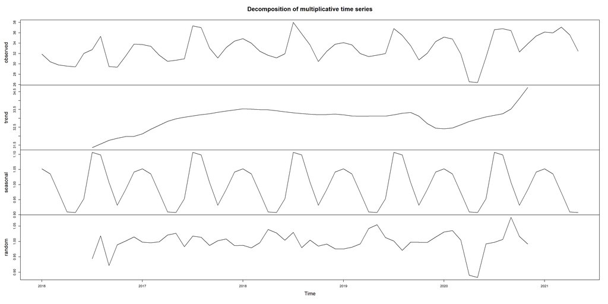

```r
data_mon_mult<-decompose(data_mon_ts,type="multiplicative")
random=data_mon_mult$random
plot(data_mon_mult)
```

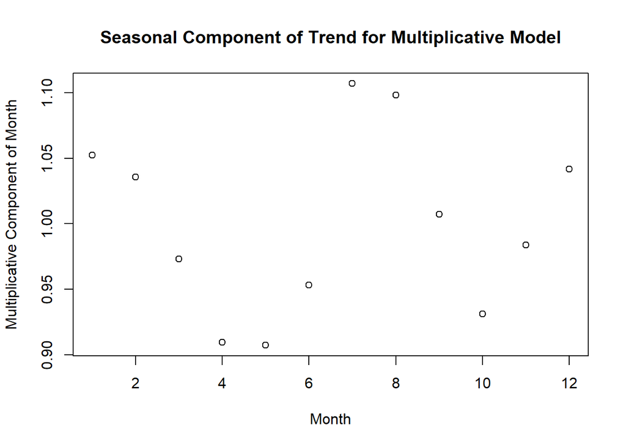

```r
plot(data_mon_mult$seasonal[1:12], xlab = "Month", ylab = "Multiplicative Component of Month", main = "Seasonal Component of Trend for Multiplicative Model")
```

The most electricity consumption occurs at the hottest seasons on July and August which can be explained by air conditioners to cool the places. It is also high during the winter for the heating purposes.

```r
unt_test=ur.kpss(data_mon_mult$random)
summary(unt_test)
```

```
##
## #######################
## # KPSS Unit Root Test #
## #######################
##
## Test is of type: mu with 3 lags.
##
## Value of test-statistic is: 0.05
##
## Critical value for a significance level of:
##                 10pct  5pct 2.5pct  1pct
## critical values 0.347 0.463  0.574 0.739
```

Yes remaining data seems random.

Let’s check the additive model.

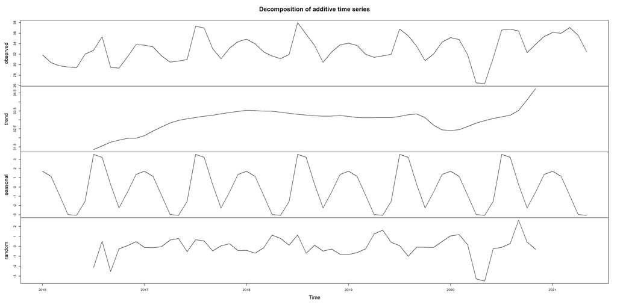

```r
data_mon_add<-decompose(data_mon_ts,type="additive")
random=data_mon_add$random
plot(data_mon_add)
```

The same comments for multiplicative decomposition is applicable here. Have a close look to seasonality:

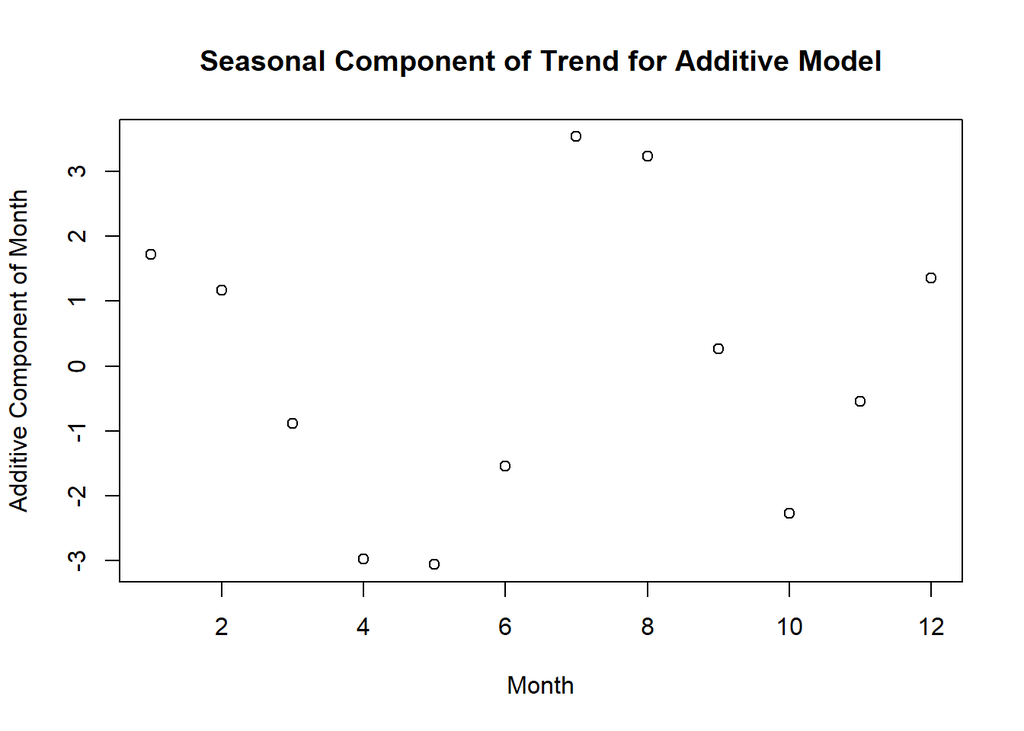

```r
plot(data_mon_add$seasonal[1:12], xlab = "Month", ylab = "Additive Component of Month", main = "Seasonal Component of Trend for Additive Model")
```

The same comments for multiplicative decomposition is applicable here. For stationary:

```r
unt_test=ur.kpss(data_mon_add$random)
summary(unt_test)
```

```
##
## #######################
## # KPSS Unit Root Test #
## #######################
##
## Test is of type: mu with 3 lags.
##
## Value of test-statistic is: 0.0552
##
## Critical value for a significance level of:
##                 10pct  5pct 2.5pct  1pct
## critical values 0.347 0.463  0.574 0.739
```

Yes remaining data seems random with a really close value to the multiplicative model.

### Question 2

We have observe that there is a weekly trend on the data on Question 1. I also examine the trend graph for hourly and daily to see their pattern both and I checked for autocorrelation and partial autocorrelations. Here I will think both the hour and the day of the observation define the seasonality. Let’s have a new time series with a frequency of 168 hours and examine the decomposition.

```r
datats_2<-ts(data$cons,freq=168)
```

To determine the decomposition method, Again, I will try both additive and multiplicative methods and see the remaining part of the data to determine the stationary of the random part.

Starting with the multiplicative decomposition:

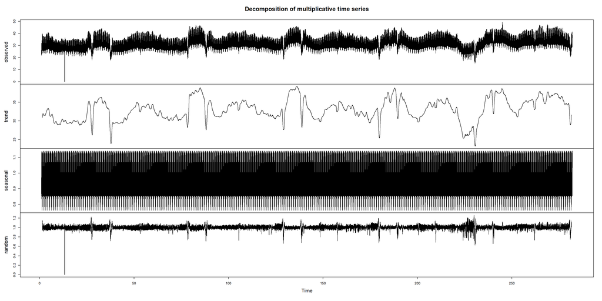

```r
data_mult_2<-decompose(datats_2,type="multiplicative")
random=data_mult_2$random
plot(data_mult_2)
```

Trend data seems to catch the overall trend. However, there is another seasonality in the trend itself that can be explained by monthly or seasonal (winter, summer, etc.) trend. During the summer the consumption is higher because of the air conditioner and we can see that in the trend. Random term seems random in a general look, with some peaks due to the speacial days or events such as covid-19 or religious holidays. There is outlier of the Error in an early period with a 0 consumption, on 2016-03-27, which can be lack of data or complete electricity interreption.

We cannot see the seasonality component from here as there are too many points. Let’s give the seasonality a close look.

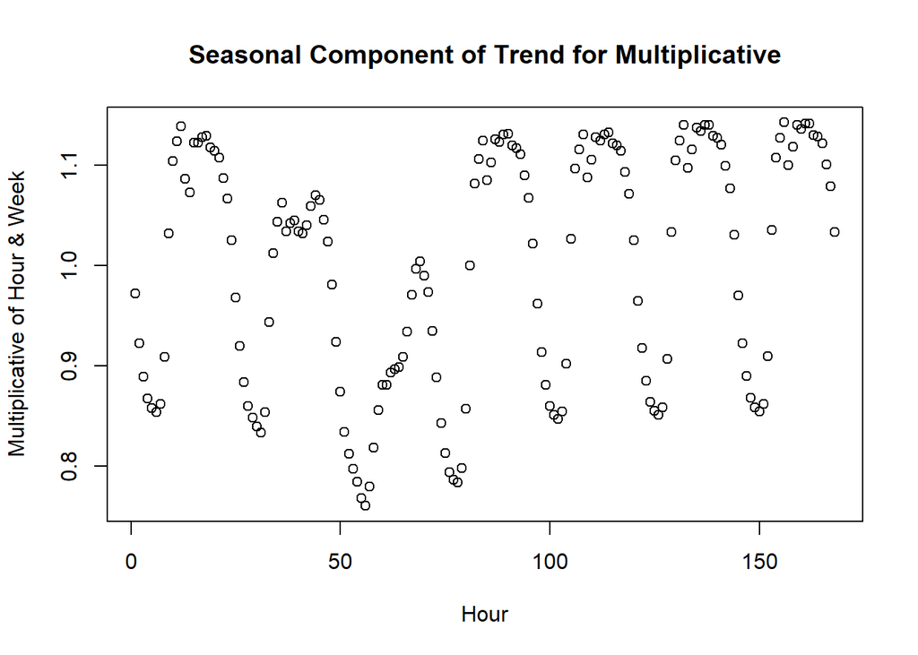

```r
plot(data_mult_2$seasonal[1:168], xlab = "Hour", ylab = "Multiplicative of Hour & Week", main = "Seasonal Component of Trend for Multiplicative")
```

Each day has its maximum use hour, we can see that from the 7 peaks at the data. The hourly multiplicatives were discussed in Question 1. The third peak is lower than the other, that can be explained with Sunday data due to the lower consumption, also discussed in Question 1.

To determine whether the remaining data is randomized, let’s see the KPSS test:

```r
unt_test=ur.kpss(data_mult_2$random)
summary(unt_test)
```

```
##
## #######################
## # KPSS Unit Root Test #
## #######################
##
## Test is of type: mu with 18 lags.
##
## Value of test-statistic is: 0.0537
##
## Critical value for a significance level of:
##                 10pct  5pct 2.5pct  1pct
## critical values 0.347 0.463  0.574 0.739
```

Differencing results in 0.0537<0.347 implies corresponding the p-value is larger than 10%, we fail to reject the null hypothesis claiming the data are stationary.

Let’s check additive model and compare those.

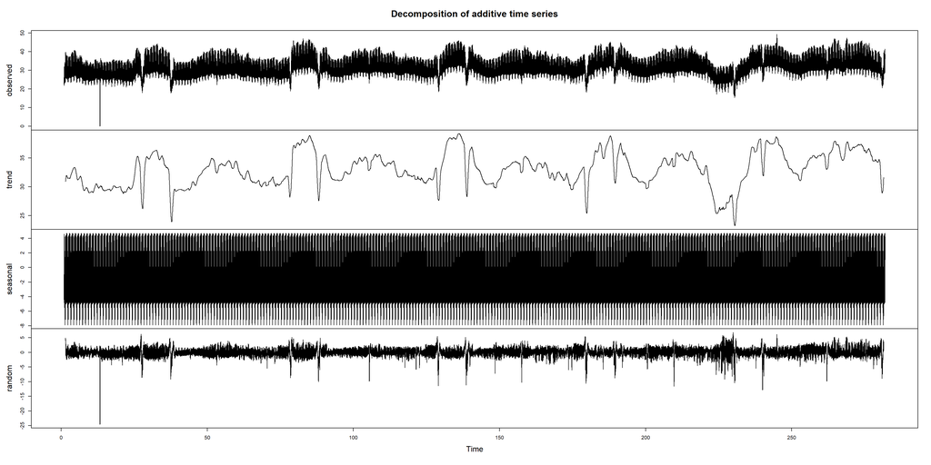

```r
data_add_2<-decompose(datats_2,type="additive")
random_add_final=data_add_2$random
plot(data_add_2)
```

Trend and random factor is pretty similar of the two model but with different parameters.

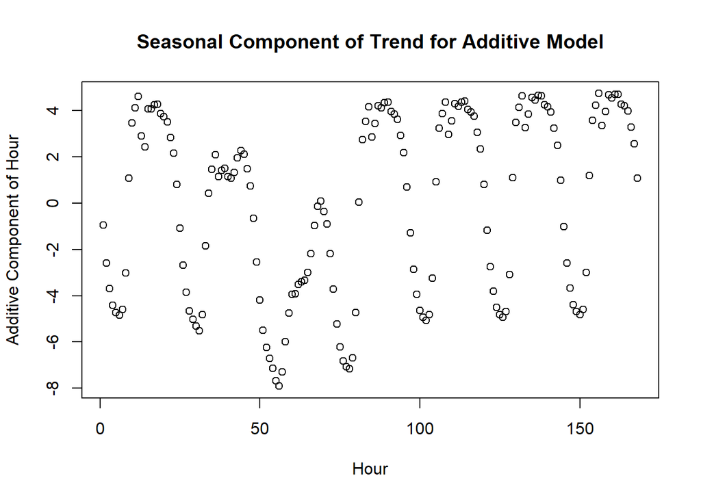

```r
plot(data_add_2$seasonal[1:168], xlab = "Hour", ylab = "Additive Component of Hour", main = "Seasonal Component of Trend for Additive Model")
```

We see same pattern, but with different parameters.

```r
unt_test=ur.kpss(data_add_2$random)
summary(unt_test)
```

```
##
## #######################
## # KPSS Unit Root Test #
## #######################
##
## Test is of type: mu with 18 lags.
##
## Value of test-statistic is: 0.0042
##
## Critical value for a significance level of:
##                 10pct  5pct 2.5pct  1pct
## critical values 0.347 0.463  0.574 0.739
```

As test-statistics lower with additive value, I will continue with my analysis on Question 3 and 4 with additive decomposition.

### Question 3

I have made the decomposition on Question 2 and found a stationary detrend remaining result. Let’s examine the detrend part and determine a AR model with a lowest AIC value.

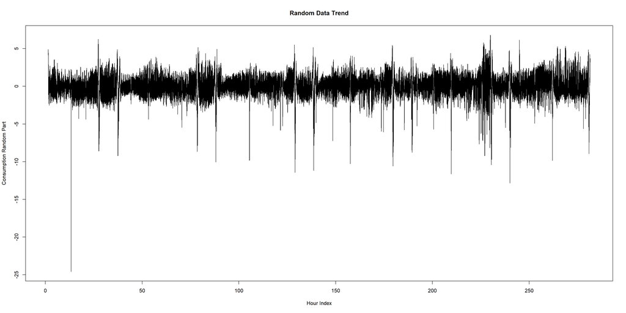

```r
#random_add_final_ts <- ts(random_add_final)

plot(random_add_final, xlab = "Hour Index", ylab = "Consumption Random Part", main = "Random Data Trend")
```

In general it seems random, as also the KPSS test suggested. We have mentioned the peak points and there results in the previous questions.

Let’s check the autocorrelation and partial autocorrelation of randomized meaning detrend part.For the AR model our main concern will be the autocorrelation plot.

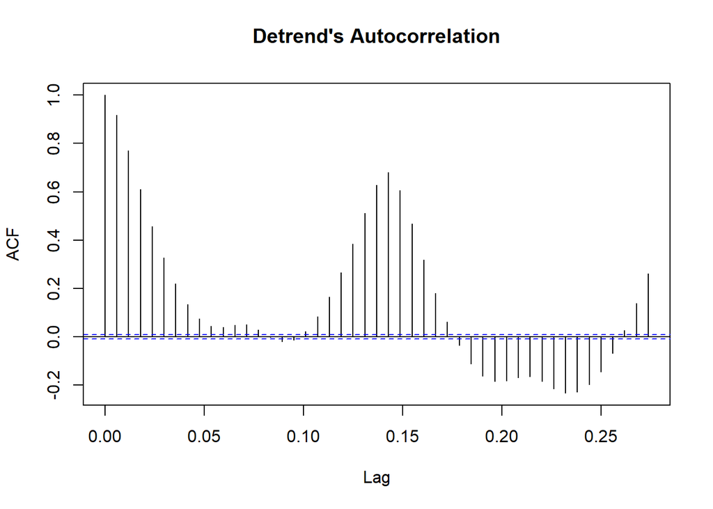

```r
acf(random_add_final, na.action = na.pass, main= "Detrend's Autocorrelation")
```

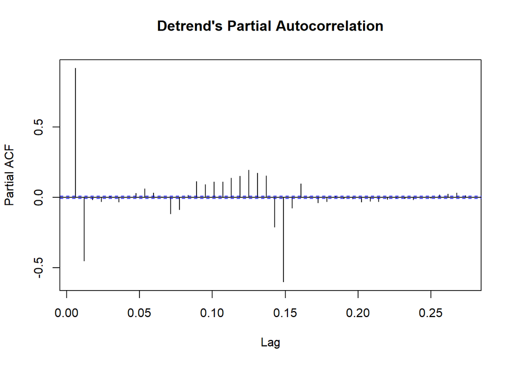

```r
pacf(random_add_final, na.action = na.pass, main = "Detrend's Partial Autocorrelation")
```

We see significant ACF, It decreases until 10, so I will start trial with AR(10) which equals ARIMA(10,0,0). The autoregressive order p.

```r
library(stats)
model <- arima(random_add_final, order=c(10,0,0))
print(model)
```

```
##
## Call:
## arima(x = random_add_final, order = c(10, 0, 0))
##
## Coefficients:
##          ar1      ar2     ar3      ar4     ar5      ar6      ar7      ar8
##       1.3212  -0.4407  0.0290  -0.0546  0.0520  -0.0228  -0.0107  -0.0386
## s.e.  0.0046   0.0076  0.0079   0.0079  0.0079   0.0079   0.0079   0.0079
##          ar9    ar10  intercept
##       0.0191  0.0339    -0.0011
## s.e.  0.0076  0.0046     0.0215
##
## sigma^2 estimated as 0.2741:  log likelihood = -36308.11,  aic = 72640.21
```

```r
AIC(model)
```

```
## [1] 72640.21
```

```r
BIC(model)
```

```
## [1] 72745.32
```

Then as on lag 1 it is extremely high, I will try AR(1).

```r
model <- arima(random_add_final, order=c(1,0,0))
print(model)
```

```
##
## Call:
## arima(x = random_add_final, order = c(1, 0, 0))
##
## Coefficients:
##          ar1  intercept
##       0.9177    -0.0011
## s.e.  0.0018     0.0330
##
## sigma^2 estimated as 0.3474:  log likelihood = -41883.4,  aic = 83772.8
```

```r
AIC(model)
```

```
## [1] 83772.8
```

```r
BIC(model)
```

```
## [1] 83799.08
```

The AIC values are way higher than at AR(10). So AR(10) is better.

As AR(10) was better, we can increase to AR(11) and compare AIC.

```r
model <- arima(random_add_final, order=c(11,0,0))
print(model)
```

```
##
## Call:
## arima(x = random_add_final, order = c(11, 0, 0))
##
## Coefficients:
##          ar1      ar2     ar3      ar4     ar5      ar6      ar7      ar8
##       1.3210  -0.4408  0.0292  -0.0545  0.0521  -0.0231  -0.0104  -0.0387
## s.e.  0.0046   0.0076  0.0079   0.0079  0.0079   0.0079   0.0079   0.0079
##          ar9    ar10    ar11  intercept
##       0.0214  0.0271  0.0051    -0.0011
## s.e.  0.0079  0.0076  0.0046     0.0216
##
## sigma^2 estimated as 0.2741:  log likelihood = -36307.49,  aic = 72640.97
```

```r
AIC(model)
```

```
## [1] 72640.97
```

```r
BIC(model)
```

```
## [1] 72754.84
```

```r
model <- arima(random_add_final, order=c(9,0,0))
print(model)
```

```
##
## Call:
## arima(x = random_add_final, order = c(9, 0, 0))
##
## Coefficients:
##          ar1      ar2     ar3      ar4     ar5      ar6      ar7      ar8
##       1.3234  -0.4426  0.0287  -0.0554  0.0538  -0.0247  -0.0097  -0.0536
## s.e.  0.0046   0.0076  0.0079   0.0079  0.0079   0.0079   0.0079   0.0076
##          ar9  intercept
##       0.0640    -0.0011
## s.e.  0.0046     0.0208
##
## sigma^2 estimated as 0.2744:  log likelihood = -36335.17,  aic = 72692.33
```

```r
AIC(model)
```

```
## [1] 72692.33
```

```r
BIC(model)
```

```
## [1] 72788.68
```

AR(10) was the lowest among all of my trials. SO this is the best model.